# Single Cell Exercise: Day 2

### Read in and set up mitochondrial genes

```r
# Specify file path to the `mm_mitochondrial_genes.tsv` file
mito_file <- file.path("data", "tabula-muris", "mm_mitochondrial_genes.tsv")
```

Read in the mitchondrial TSV file with the `readr` package and name it `mito_genes`. Filter it only to the rownames specified in the `sce` object. Lastly, use `dplyr::pull()` to vectorize only the `gene_id` column.

```r
# Read in the mitochondial genes TSV file using the readr package
mito_genes <- readr::read_tsv(mito_file) %>%
  # Filter to the genes in that are included in `rownames(sce)` object
  dplyr::filter(gene_id %in% rownames(sce)) %>%
  # Use `dplyr::pull()` to vectorize only the `gene_id` column
  dplyr::pull(gene_id)
```

### Quality control filtering with scater

Use `scater::addPerCellQC()` to calculate our QC statistics using the `mito_genes`. Store this back into `sce`.

```r
# Use scater::addPerCellQC where subsets are specified as a list version of `mito_genes`.
sce <- scater::addPerCellQC(sce,
                            subsets = list(mito = mito_genes))
```

Let’s make some plots of the QC data and use it to inform our next steps. Create a data.frame from metadata for each cell (the `colData` for the `SingleCellExperiment` object.)

```r
# Turn the `colData` for the `SingleCellExperiment` object into its own data.frame called `cell_qc_df`.
cell_qc_df <- as.data.frame(colData(sce))
```

Use the `cell_qc_df` data frame we just created, to make some plots that can help you decide on cutoffs! Your plots should help you decide what mitochondrial percentage cutoff is acceptable per cell.

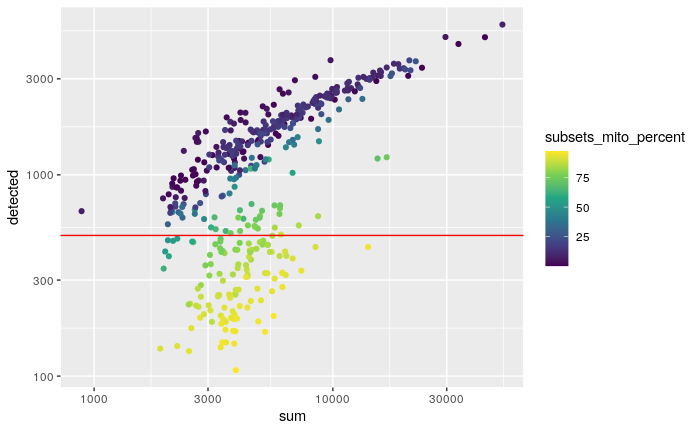

```r
ggplot(cell_qc_df,
       aes(x = sum, y = detected, color = subsets_mito_percent)) +
  geom_point() +
  scale_color_viridis_c() +
  scale_x_log10() +
  scale_y_log10() +
  geom_hline(yintercept = 500, color = "red")
```

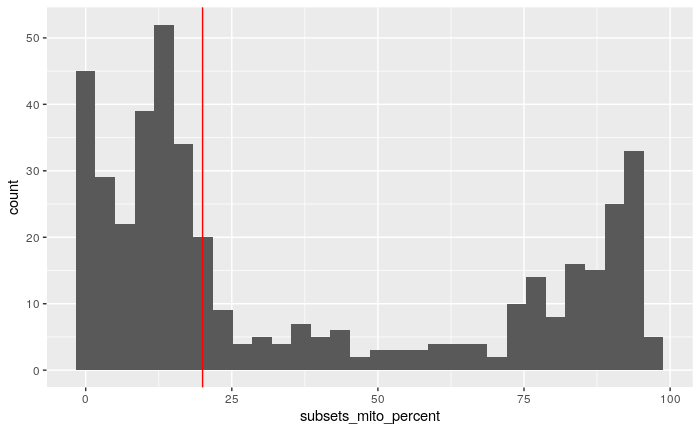

```r
ggplot(cell_qc_df,
       aes(x = subsets_mito_percent)) +
  geom_histogram() +
  geom_vline(xintercept = 20, color = "red")
```

Using your QC and plots, create a subset of the `SingleCellExperiment` object, keeping only the columns (samples) that pass your thresholds for the `sce` categories: `$detected` and `$subsets_mito_percent` for each cell.

```r
# Create sce_filtered object with just the cells that pass your decided upon filters
# Construct a logical statement to determine which cells pass your QC filter for
qc_pass <- (sce$detected > 500) & (sce$subsets_mito_percent < 20)

# Apply the filter to SCE filter
sce_filtered <- sce[, qc_pass]
```

Calculate QC stats for your genes using `scater::addPerFeatureQC()` on your `sce_filtered`.

```r
# Calculate QC stats for your genes by using scater::addPerFeatureQC()
sce_filtered <- scater::addPerFeatureQC(sce_filtered)
```

Use the QC data (stored in `rowData` of your `sce_filtered`) to filter by row to only the genes. Decide upon a threshold for: - a minimum number of `detected` cells per gene - a minimum mean `expression` count per gene You an use `>5` cells and `> 0.1` mean expression if you wish.

Create a logical expression for the minimum number of detected cells per gene

```r
# Create a logical expression for the minimum number of detected cells per gene
detected <- rowData(sce_filtered)$detected > 5
```

```r
# Create a logical expression for the minimum number of detected cells per gene
expressed <- rowData(sce_filtered)$mean > 0.1
```

Filter `sce_filtered` by only including those genes that are `TRUE` for both the minimum thresholds. (Use `&` with the logical expressions you set up in the last steps)

```r
# Filter the rows (genes) by those that are TRUE for both the minimum thresholds (hint use &)
sce_filtered <- sce_filtered[detected & expressed, ]
```

### Normalize the data

Perform the same normalization steps using `scran::computeSumFactors()` and `scater::logNormCounts()` as we did in the `05-dimension_reduction_scRNA-seq.Rmd` notebook.

First cluster similar cells using `scran::quickCluster()`.

```r
# Cluster similar cells using `scran::quickCluster()`
qclust <- scran::quickCluster(sce_filtered)
```

```
collapsing to unique 'x' values
```

Use `scran::computeSumFactors()` to calculate the the sum factors so we can use them to normalize the data in the next step. You will need to specify the `clusters` argument as the object you obtained from `scran::quickCluster()` that you performed in the last step.

```r
# Compute sum factors for each cell cluster grouping for sce_filtered using the `scran::quickCluster()` you performed.
sce_filtered <- scran::computeSumFactors(sce_filtered, clusters = qclust)
```

Normalize and log transform using `scater::logNormCounts()` now that you have calculated the the sum factors (those will be store in the `sce_filtered` object).

```r
# Normalize and log transform.
sce_filtered <- scater::logNormCounts(sce_filtered)
```

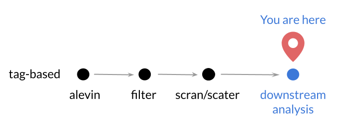

**Status of the current dataset**

### Perform dimension reduction!

Use what you have learned about `ggplot2` visualizations and create dimension reduction plots using these functions:

- `scater::calculatePCA()`
- `scater::calculateUMAP()`
- `scater::calculateTSNE()`

We recommend using multiple dimension reduction strategies since each have their own strengths and drawbacks. We will take you through the steps for PCA, but you can generally repeat these steps for each dimension reduction strategy but you’ll have to determine what changes are needed on your own. Feel free to make the plots your own. You may want to google `ggplot2` ideas for inspiration or take a look at the [ggplot2 cheatsheet](https://rstudio.com/wp-content/uploads/2015/03/ggplot2-cheatsheet.pdf) for reference.

*Step 1)* Calculate the dimension reduction.

```r
# Calculate on your normalized `sce_filtered` object
tm_pca <- scater::calculatePCA(sce_filtered)
```

*Step 2)* Prepare for plotting by combining the dimension reduction calculations with the metadata. Perform an `dplyr::inner_join()` with `tm_pca` and `metadata`.

```r
# Combine your dimension reduction results with the metadata
tm_meta_pca <- tm_pca %>%
  # You will need to use as.data.frame() to turn the colData() into a data.frame instead of a DataFrame.
  as.data.frame() %>%
  # You will also need to use tibble::rownames_to_column()
  tibble::rownames_to_column("cell_id") %>%
  # Perform an dplyr::inner_join()
  dplyr::inner_join(metadata, by = "cell_id")
```

*Step 3)* Plot the dimension reduction and using what you have learned about ggplot2.

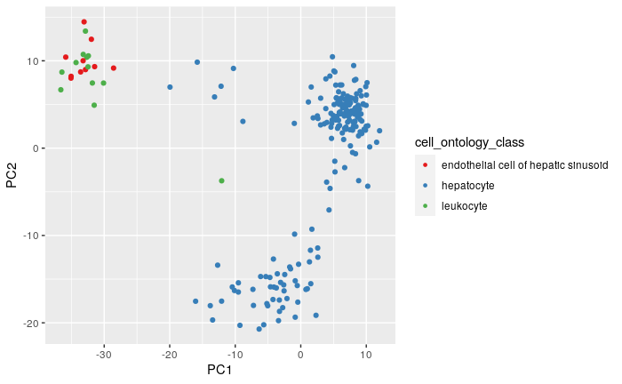

```r
# Plot first two PCA or UMAP components using ggplot2. Specify color label if desired.
ggplot(data.frame(tm_meta_pca),
       aes(x = PC1, y = PC2, color = cell_ontology_class)) +
  # Specify as plot type as geom_point()
  geom_point() +
  # Adjust color palettes or any other customizations you desire.
  scale_color_brewer(palette = "Set1") + # a not terrible color scheme for colorblindness
  guides(color = guide_legend(override.aes = list(alpha = 1, size = 1)))
```

Use `ggplot2::ggsave()` to save your plot to the `figures` directory.

```r
# Save your plot with ggsave()
ggplot2::ggsave(file.path("figures", "pca_tabula_muris.png"))
```

Now you can repeat these general steps for the other dimension reduction strategy! Another idea is using these visualizations to compare unnormalized and normalized versions of your data.